# Portfolio Optimization Comparison

Ethan Pinto

2023-11-28

Install necessary packages:

```r
# install.packages("quantmod")
# install.packages("PerformanceAnalytics")
# install.packages("tseries")
# install.packages("R.matlab")
# install.packages("tidyquant")
# install.packages("tidyr")
# install.packages("dplyr")
```

Load Libraries:

```r
library(quantmod)
library(PerformanceAnalytics)
```

```r
library(xts)
library(tseries)
library(quadprog)
library(ggplot2)
library(tidyquant)
library(tidyr)
library(dplyr)
```

The first step is to pull in the historical stock data that we will use to create our portfolio and pass through the models:

```r
stocks <- c("AAPL","MSFT", "GE", "LMT", "PFE", "NVO", "AMZN", "TSLA", "WFC", "BLK")

startDate <- as.Date("2018-01-01")
endDate <- as.Date("2022-10-31")

stockData <- list()

for (stock in stocks) {
  stockData[[stock]] <- getSymbols(stock, src = "yahoo",
                                   from = startDate,
                                   to = endDate,
                                   auto.assign = FALSE)
}

stockPrices <- do.call(merge, lapply(stockData@.Data, function(x) Ad(x)))
```

Next, we will build the (equally weighted) portfolio:

```r
prices <- do.call(merge, lapply(stockData, Ad))

returns <- Return.calculate(prices)
returns[is.na(returns)] <- 0

numStocks <- length(stockData)
weights <- rep(1/numStocks, numStocks)

portfolioReturns <- Return.portfolio(R = returns, weights = weights)

head(portfolioReturns)
```

```
##            portfolio.returns
## 2018-01-02       0.000000000
## 2018-01-03       0.006011433
## 2018-01-04       0.007244349
## 2018-01-05       0.007751192
## 2018-01-08       0.003792290
## 2018-01-09       0.003213404
```

With this portfolio, we can now start testing our portfolio optimization methods.

The first method is Value-at-Risk and Conditional Value-at-Risk

```r
confidenceLevel <- 0.95

VaR_Historical <- VaR(portfolioReturns, p = confidenceLevel, method = "historical")

CVaR_Historical <- ES(portfolioReturns, p = confidenceLevel, method = "historical")

cat("Historical VaR at", confidenceLevel*100, "% confidence level is:", VaR_Historical, "\n")
```

```
## Historical VaR at 95 % confidence level is: -0.03115543
```

```r
cat("Historical CVaR at", confidenceLevel*100, "% confidence level is:", CVaR_Historical, "\n")
```

```
## Historical CVaR at 95 % confidence level is: -0.04622044
```

Next we will run a Monte Carlo simulation:

```r
monteCarloOptimization <- function(returns, numPortfolios = 10000) {
  numAssets <- ncol(returns)
  results <- matrix(0, nrow = numPortfolios, ncol = 3 + numAssets)  # Extend matrix to store weights

  colnames(results) <- c("Return", "Risk", "Sharpe", paste("Weight", 1:numAssets, sep = "_"))

  for (i in 1:numPortfolios) {
    weights <- runif(numAssets)
    weights <- weights / sum(weights)

    portfolioReturn <- sum(apply(returns, 1, function(x) sum(x * weights)))
    portfolioRisk <- sqrt(t(weights) %*% cov(returns) %*% weights)
    sharpeRatio <- portfolioReturn / portfolioRisk

    results[i,] <- c(portfolioReturn, portfolioRisk, sharpeRatio, weights)

  }

  return(results)
}

mcResults <- monteCarloOptimization(returns)

optimalPortfolio <- mcResults[which.max(mcResults[, "Sharpe"]),]

cat("Optimal Portfolio:\n")
```

```
## Optimal Portfolio:
```

```r
cat(sprintf("Return: %f\n", optimalPortfolio["Return"]))
```

```
## Return: 1.600277
```

```r
cat(sprintf("Risk: %f\n", optimalPortfolio["Risk"]))
```

```
## Risk: 0.016983
```

```r
cat(sprintf("Sharpe Ratio: %f\n", optimalPortfolio["Sharpe"]))
```

```
## Sharpe Ratio: 94.227205
```

```r
numAssets <- ncol(returns)
for (j in 1:numAssets) {
  cat(sprintf("Weight of Asset %d: %f\n", j, optimalPortfolio[paste("Weight", j, sep = "_")]))
}
```

```
## Weight of Asset 1: 0.089983
## Weight of Asset 2: 0.030653
## Weight of Asset 3: 0.003950
## Weight of Asset 4: 0.031873
## Weight of Asset 5: 0.206962
## Weight of Asset 6: 0.250239
## Weight of Asset 7: 0.085758
## Weight of Asset 8: 0.267519
## Weight of Asset 9: 0.020181
## Weight of Asset 10: 0.012883
```

Next, we will do CAPM optimization. First, calculate the stock returns for further analysis:

```r
stocks <- c("AAPL","MSFT", "GE", "LMT", "PFE", "NVO", "AMZN", "TSLA", "WFC", "BLK")

startDate <- as.Date("2018-01-01")
endDate <- as.Date("2022-10-31")

stockReturns <- list()

for (stock in stocks) {
  tempReturns <- Delt(Ad(stockData[[stock]]))
  tempReturns[1, ] <- 0  # Set the first day's return to 0
  stockReturns[[stock]] <- tempReturns
}

mergedReturns <- do.call(merge, stockReturns)

head(mergedReturns)
```

```
##            Delt.1.arithmetic Delt.1.arithmetic.1 Delt.1.arithmetic.2
## 2018-01-02       0.000000000        0.0000000000        0.0000000000
## 2018-01-03      -0.000174141        0.0046538648        0.0094550831
## 2018-01-04       0.004645007        0.0088014679        0.0209365040
## 2018-01-05       0.011385554        0.0123979846        0.0005396223
## 2018-01-08      -0.003714225        0.0010206830       -0.0140236180
## 2018-01-09      -0.000114764       -0.0006794837        0.0153172270
##            Delt.1.arithmetic.3 Delt.1.arithmetic.4 Delt.1.arithmetic.5
## 2018-01-02         0.000000000         0.000000000        0.0000000000
## 2018-01-03         0.008382108         0.007409472        0.0096013389
## 2018-01-04         0.017153680         0.002179333       -0.0034746850
## 2018-01-05         0.009059648         0.001902770        0.0045877822
## 2018-01-08        -0.004610340        -0.011123219       -0.0009132804
## 2018-01-09         0.007161003        -0.001097439        0.0031083693
##            Delt.1.arithmetic.6 Delt.1.arithmetic.7 Delt.1.arithmetic.8
## 2018-01-02         0.000000000         0.000000000         0.000000000
## 2018-01-03         0.012775310        -0.010233113         0.007693562
## 2018-01-04         0.004476013        -0.008289978         0.012508093
## 2018-01-05         0.016162517         0.006229741         0.006738352
## 2018-01-08         0.014424679         0.062638220        -0.011314616
## 2018-01-09         0.004675710        -0.008085381         0.003545651
##            Delt.1.arithmetic.9
## 2018-01-02         0.000000000
## 2018-01-03         0.010550846
## 2018-01-04         0.013201333
## 2018-01-05         0.008519984
## 2018-01-08         0.007458555
## 2018-01-09         0.008404273
```

Next, we will need to pull in Market return data:

```r
sp500Data <- getSymbols("^GSPC", src = "yahoo", from = startDate, to = endDate, auto.assign = FALSE)

if (is.null(sp500Data)) {
  stop("Failed to retrieve S&P 500 data")
} else {

  sp500Close <- Ad(sp500Data)

  marketReturn <- Return.calculate(sp500Close)

  marketReturn[1,] <- 0

  head(marketReturn)
}
```

```
##            GSPC.Adjusted
## 2018-01-02   0.000000000
## 2018-01-03   0.006398819
## 2018-01-04   0.004028636
## 2018-01-05   0.007033767
## 2018-01-08   0.001662344
## 2018-01-09   0.001302932
```

Next, we calculate the Beta using the CAPM method:

```r
calculateBeta <- function(mergedReturns, marketReturn) {

  combinedData <- cbind(coredata(mergedReturns), coredata(marketReturn))

  covMat <- cov(combinedData)

  beta <- covMat[1, 2] / var(coredata(marketReturn))
  return(beta)
}

capmOptimization <- function(mergedReturns, marketReturn, riskFreeRate) {
  numAssets <- ncol(mergedReturns)
  betas <- numeric(numAssets)

  for (i in 1:numAssets) {
    betas[i] <- calculateBeta(mergedReturns[, i], marketReturn)
  }

  expectedReturns <- riskFreeRate + betas * (mean(marketReturn, na.rm = TRUE) - riskFreeRate)

  covReturns <- cov(mergedReturns, use = "pairwise.complete.obs")

  Dmat <- 2 * covReturns
  dvec <- rep(0, numAssets)
  Amat <- rbind(1, diag(numAssets))
  bvec <- c(1, rep(0, numAssets))

  portfolioOptim <- solve.QP(Dmat, dvec, t(Amat), bvec, meq = 1)

  portfolioWeights <- portfolioOptim$solution

  return(list(betas = betas, expectedReturns = expectedReturns, weights = portfolioWeights))
}

riskFreeRate <- 0.015

capmResults <- capmOptimization(mergedReturns, marketReturn, riskFreeRate)

format(capmResults, scientific = FALSE)
```

```
##                                                                                                                                                                                                                                                                                               betas
##                                                                                                                                                                                      "1.2153067, 1.2030067, 1.1398328, 0.6943240, 0.6195502, 0.5809871, 1.0689141, 1.4330871, 1.1887334, 1.2212237"
##                                                                                                                                                                                                                                                                                     expectedReturns
##                                                                                                                                                 "-0.0027448360, -0.0025652424, -0.0016428319, 0.0048620942, 0.0059538748, 0.0065169399, -0.0006073399, -0.0059246723, -0.0023568364, -0.0028312301"
##                                                                                                                                                                                                                                                                                             weights
## "0.0000000000000000000000000, -0.0000000000000000001319786, 0.0174174226883696790790790, 0.2708489615816870865749877, 0.2682033891351394694346766, 0.2935596103868725603724954, 0.1279709420708866063343123, 0.0021416117236306591621597, 0.0198580624134140244774205, 0.0000000000000000026930492"
```

```r
print(capmResults)
```

```
## $betas
##  [1] 1.2153067 1.2030067 1.1398328 0.6943240 0.6195502 0.5809871 1.0689141
##  [8] 1.4330871 1.1887334 1.2212237
##
## $expectedReturns
##  [1] -0.0027448360 -0.0025652424 -0.0016428319  0.0048620942  0.0059538748
##  [6]  0.0065169399 -0.0006073399 -0.0059246723 -0.0023568364 -0.0028312301
##
## $weights
##  [1]  0.000000e+00 -1.319786e-19  1.741742e-02  2.708490e-01  2.682034e-01
##  [6]  2.935596e-01  1.279709e-01  2.141612e-03  1.985806e-02  2.693049e-18
```

Markowitz Optimization

```r
markowitzOptimization <- function(mergedReturns, riskFreeRate) {
  numAssets <- ncol(mergedReturns)

  meanReturns <- colMeans(mergedReturns)
  covReturns <- cov(mergedReturns)

  Dmat <- 2 * covReturns
  dvec <- rep(0, numAssets)

  if (!is.matrix(Dmat) || nrow(Dmat) != ncol(Dmat) || nrow(Dmat) != length(dvec)) {
    stop("Dmat or dvec dimension error")
  }

  Amat <- rbind(1, diag(numAssets))
  bvec <- c(1, rep(0, numAssets))

  if (ncol(Amat) != length(dvec) || nrow(Amat) != length(bvec)) {
    stop("Amat or bvec dimension error")
  }

  sol <- solve.QP(Dmat, dvec, t(Amat), bvec, meq = 1)

  weights <- sol$solution
  return(weights)
}

riskFreeRate <- 0.015

optimalWeights <- markowitzOptimization(mergedReturns, riskFreeRate)

format(optimalWeights, scientific = FALSE)
```

```
##  [1] " 0.0000000000000000000000000" "-0.0000000000000000001319786"
##  [3] " 0.0174174226883696790790790" " 0.2708489615816870865749877"
##  [5] " 0.2682033891351394694346766" " 0.2935596103868725603724954"
##  [7] " 0.1279709420708866063343123" " 0.0021416117236306591621597"
##  [9] " 0.0198580624134140244774205" " 0.0000000000000000026930492"
```

```r
print(optimalWeights)
```

```
##  [1]  0.000000e+00 -1.319786e-19  1.741742e-02  2.708490e-01  2.682034e-01
##  [6]  2.935596e-01  1.279709e-01  2.141612e-03  1.985806e-02  2.693049e-18
```

(I also have a black litterman function i want to add here when I figure it out)

Mean Variance Frontier

```r
meanVarianceFrontier <- function(mergedReturns, riskFreeRate, targetReturns) {
  numAssets <- ncol(mergedReturns)
  meanReturns <- colMeans(mergedReturns)
  covReturns <- cov(mergedReturns)

  Dmat <- 2 * covReturns
  dvec <- rep(0, numAssets)

  risks <- numeric(length(targetReturns))
  weightsList <- vector("list", length(targetReturns))

  for (i in seq_along(targetReturns)) {
    Amat <- rbind(1, diag(numAssets), meanReturns)
    bvec <- c(1, rep(0, numAssets), targetReturns[i])

    sol <- solve.QP(Dmat, dvec, t(Amat), bvec, meq = 2)

    risks[i] <- sqrt(t(sol$solution) %*% covReturns %*% sol$solution)
    weightsList[[i]] <- sol$solution
  }

  efficientFrontier <- data.frame(Return = targetReturns, Risk = risks, Weights = weightsList)

  return(efficientFrontier)
}

targetReturns <- seq(from = min(colMeans(mergedReturns)), to = max(colMeans(mergedReturns)), length.out = 10)
riskFreeRate <- 0.015
frontier <- meanVarianceFrontier(mergedReturns, riskFreeRate, targetReturns)

print(frontier)
```

```
##           Return       Risk
## 1  -4.634187e-05 0.01225770
## 2   2.689091e-04 0.01225770
## 3   5.841600e-04 0.01225770
## 4   8.994110e-04 0.01280337
## 5   1.214662e-03 0.01523553
## 6   1.529913e-03 0.01916682
## 7   1.845164e-03 0.02391364
## 8   2.160415e-03 0.02922132
## 9   2.475666e-03 0.03499802
## 10  2.790917e-03 0.04107459
##    Weights.c.0...1.31978639907573e.19..0.0174174226883697..0.270848961581687..
## 1                                                                 0.000000e+00
## 2                                                                -1.319786e-19
## 3                                                                 1.741742e-02
```

[output cut: 106 more lines]

Visualize the Mean Variance Frontier

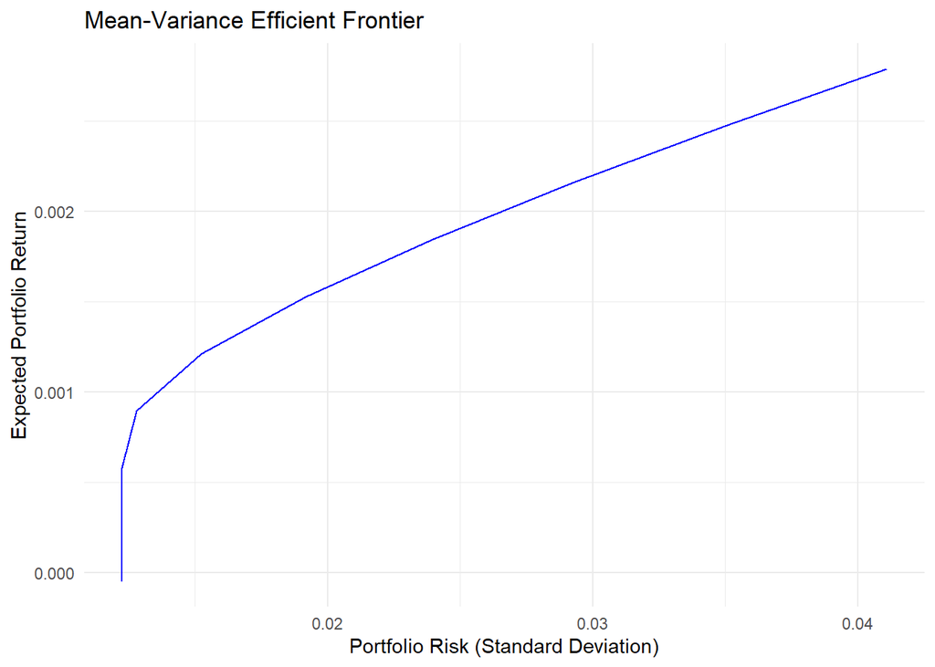

```r
ggplot(frontier, aes(x = Risk, y = Return)) +
  geom_line(color = "blue") +
  labs(title = "Mean-Variance Efficient Frontier",
       x = "Portfolio Risk (Standard Deviation)",
       y = "Expected Portfolio Return") +
  theme_minimal()
```

Next, we pull in data from after our historical period to test each portfolio against: (Note, important to run this chunk again to overwrite the original (historical) data from the previous chunks)

```r
stocks <- c("AAPL","MSFT", "GE", "LMT", "PFE", "NVO", "AMZN", "TSLA", "WFC", "BLK")

startDate <- as.Date("2023-01-01")
endDate <- as.Date("2023-10-31")

stockData <- list()

for (stock in stocks) {
  stockData[[stock]] <- getSymbols(stock, src = "yahoo",
                                   from = startDate,
                                   to = endDate,
                                   auto.assign = FALSE)
}

stockReturn <- list()

for (stock in stocks) {
  tempReturns <- Delt(Ad(stockData[[stock]]))
  tempReturns[1, ] <- 0
  stockReturn[[stock]] <- tempReturns
}

stockReturns <- do.call(merge, stockReturn)

head(stockReturns)
```

```
##            Delt.1.arithmetic Delt.1.arithmetic.1 Delt.1.arithmetic.2
## 2023-01-03       0.000000000         0.000000000         0.000000000
## 2023-01-04       0.010314283        -0.043743227         0.058204185
## 2023-01-05      -0.010604730        -0.029637684         0.015527052
## 2023-01-06       0.036794126         0.011785399         0.009117706
## 2023-01-09       0.004088992         0.009736197         0.010147280
## 2023-01-10       0.004456326         0.007617200         0.035778142
##            Delt.1.arithmetic.3 Delt.1.arithmetic.4 Delt.1.arithmetic.5
## 2023-01-03         0.000000000         0.000000000         0.000000000
## 2023-01-04        -0.002156975        -0.022044424        -0.001387312
## 2023-01-05         0.001196200        -0.009375697        -0.003802123
## 2023-01-06        -0.008028137         0.025372509         0.017541330
## 2023-01-09        -0.030111597        -0.049685684        -0.010170301
## 2023-01-10         0.007189739        -0.015912385        -0.026014578
##            Delt.1.arithmetic.6 Delt.1.arithmetic.7 Delt.1.arithmetic.8
## 2023-01-03         0.000000000         0.000000000        0.0000000000
## 2023-01-04        -0.007923565         0.051248853        0.0205790589
## 2023-01-05        -0.023725589        -0.029039098       -0.0053927868
## 2023-01-06         0.035611152         0.024651090        0.0089579737
## 2023-01-09         0.014869874         0.059349011       -0.0095793148
## 2023-01-10         0.028731709        -0.007681374       -0.0007076527
##            Delt.1.arithmetic.9
## 2023-01-03         0.000000000
## 2023-01-04         0.013847464
## 2023-01-05        -0.028618845
## 2023-01-06         0.052421341
## 2023-01-09         0.020311699
## 2023-01-10         0.005697328
```

Equally Weighted Portfolio Returns (re-running this chunk using the new data)

```r
prices <- do.call(merge, lapply(stockData, Ad))


returns <- Return.calculate(prices)
returns[is.na(returns)] <- 0

numStocks <- length(stockData)
weights <- rep(1/numStocks, numStocks)


portfolioReturns <- Return.portfolio(R = returns, weights = weights)

tail(portfolioReturns)
```

```
##            portfolio.returns
## 2023-10-23      0.0031114703
## 2023-10-24      0.0122825494
## 2023-10-25     -0.0098386475
## 2023-10-26     -0.0174554965
## 2023-10-27      0.0003512552
## 2023-10-30      0.0122524775
```

Monte Carlo Optimization Returns

(get weights from function return)

```r
mc_weights <- c(0.21859, 0.08281, 0.188986, 0.01652, 0.000796, 0.19554, 0.098302, 0.108662, 0.036544, 0.053249)

mc_portfolioReturns <- Return.portfolio(R = returns, weights = mc_weights)
tail(mc_portfolioReturns)
```

```
##            portfolio.returns
## 2023-10-23      0.0043549297
## 2023-10-24      0.0193693869
## 2023-10-25     -0.0136348172
## 2023-10-26     -0.0228415861
## 2023-10-27      0.0002376274
## 2023-10-30      0.0150845036
```

CAPM Optimization Returns

```r
capm_weights <- c(0.0000000000000000000000000, -0.0000000000000000001094735, 0.0174175751737773581995228, 0.2708490891210338369354815, 0.2682027762553574334880579, 0.2935597422412994927931607, 0.1279711440899859720143894, 0.0021415150238913334412860, 0.0198581580946546529253816, -0.0000000000000000160630695)

capm_portfolioReturns <- Return.portfolio(R = returns, weights = capm_weights)

tail(capm_portfolioReturns)
```

```
##            portfolio.returns
## 2023-10-23       0.007082206
## 2023-10-24       0.001191459
## 2023-10-25      -0.005836649
## 2023-10-26      -0.010727712
## 2023-10-27      -0.003255237
## 2023-10-30       0.023326329
```

Markowitz Optimization

```r
marko_weights <- c(0.0000000000000000000000000, -0.0000000000000000001094735, 0.0174175751737773581995228, 0.2708490891210338369354815, 0.2682027762553574334880579, 0.2935597422412994927931607,
0.1279711440899859720143894, 0.0021415150238913334412860, 0.0198581580946546529253816, -0.0000000000000000160630695)

marko_portfolioReturns <- Return.portfolio(R = returns, weights = marko_weights)

tail(marko_portfolioReturns)
```

```
##            portfolio.returns
## 2023-10-23       0.007082206
## 2023-10-24       0.001191459
## 2023-10-25      -0.005836649
## 2023-10-26      -0.010727712
## 2023-10-27      -0.003255237
## 2023-10-30       0.023326329
```

Plotting the performance of each portfolio:

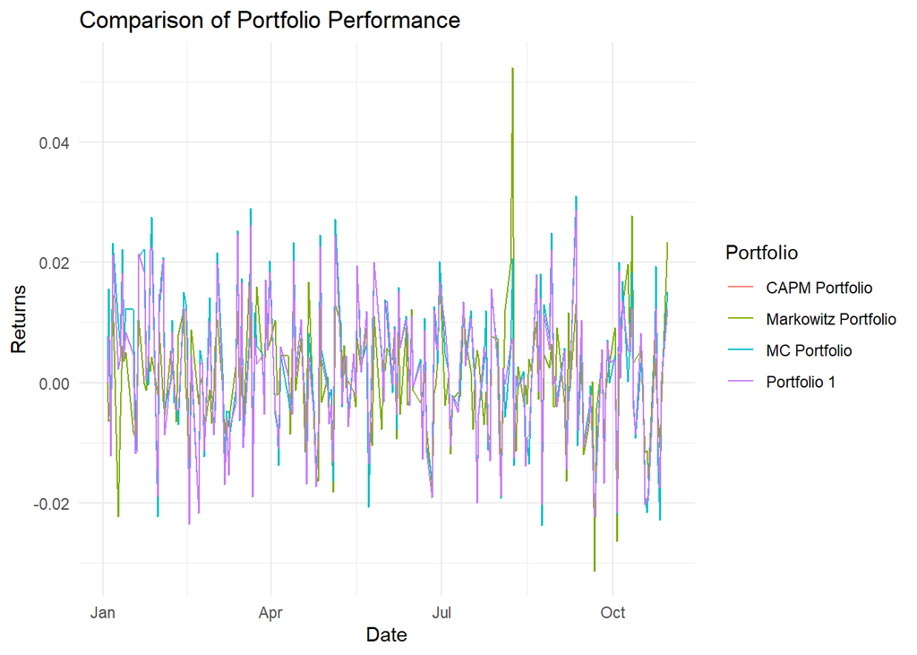

```r
portfolioReturns_df <- as.data.frame(portfolioReturns)
portfolioReturns_tibble <- as_tibble(portfolioReturns_df, rownames = "Date")

mc_portfolioReturns_df <- as.data.frame(mc_portfolioReturns)
mc_portfolioReturns_tibble <- as_tibble(mc_portfolioReturns_df, rownames = "Date")

capm_portfolioReturns_df <- as.data.frame(capm_portfolioReturns)
capm_portfolioReturns_tibble <- as_tibble(capm_portfolioReturns_df, rownames = "Date")

marko_portfolioReturns_df <- as.data.frame(marko_portfolioReturns)
marko_portfolioReturns_tibble <- as_tibble(marko_portfolioReturns_df, rownames = "Date")

portfolioReturns_tibble <- portfolioReturns_tibble %>% mutate(Portfolio = "Portfolio 1") %>% rename(Returns = portfolio.returns)
mc_portfolioReturns_tibble <- mc_portfolioReturns_tibble %>% mutate(Portfolio = "MC Portfolio") %>% rename(Returns = portfolio.returns)
capm_portfolioReturns_tibble <- capm_portfolioReturns_tibble %>% mutate(Portfolio = "CAPM Portfolio") %>% rename(Returns = portfolio.returns)
marko_portfolioReturns_tibble <- marko_portfolioReturns_tibble %>% mutate(Portfolio = "Markowitz Portfolio") %>% rename(Returns = portfolio.returns)

combinedDf <- bind_rows(
    portfolioReturns_tibble,
    mc_portfolioReturns_tibble,
    capm_portfolioReturns_tibble,
    marko_portfolioReturns_tibble
)

# Define a color palette
color_palette <- c("Portfolio 1" = "blue",
                   "MC Portfolio" = "green",
                   "CAPM Portfolio" = "red",
                   "Markowitz Portfolio" = "purple")

ggplot(combinedDf, aes(x = as.Date(Date), y = Returns, color = Portfolio)) +
    geom_line() +
    labs(title = "Comparison of Portfolio Performance", x = "Date", y = "Returns") +
    theme_minimal()
```

Calculate and graph the variance of each portfolio:

```r
variance1 <- var(portfolioReturns, na.rm = TRUE)
variance2 <- var(mc_portfolioReturns, na.rm = TRUE)
variance3 <- var(capm_portfolioReturns, na.rm = TRUE)
variance4 <- var(marko_portfolioReturns, na.rm = TRUE)

variance_data <- data.frame(
  Portfolio = c("Equally Weighted", "Monte Carlo", "CAPM", "Markowitz"),
  Variance = c(variance1, variance2, variance3, variance4)
)

print(paste("Variance for Portfolio 1:", variance1))
```

```
## [1] "Variance for Portfolio 1: 0.000128153727390074"
```

```r
print(paste("Variance for Portfolio 2:", variance2))
```

```
## [1] "Variance for Portfolio 2: 0.000144182771129367"
```

```r
print(paste("Variance for Portfolio 3:", variance3))
```

```
## [1] "Variance for Portfolio 3: 9.25578927399404e-05"
```

```r
print(paste("Variance for Portfolio 4:", variance4))
```

```
## [1] "Variance for Portfolio 4: 9.25578927399404e-05"
```

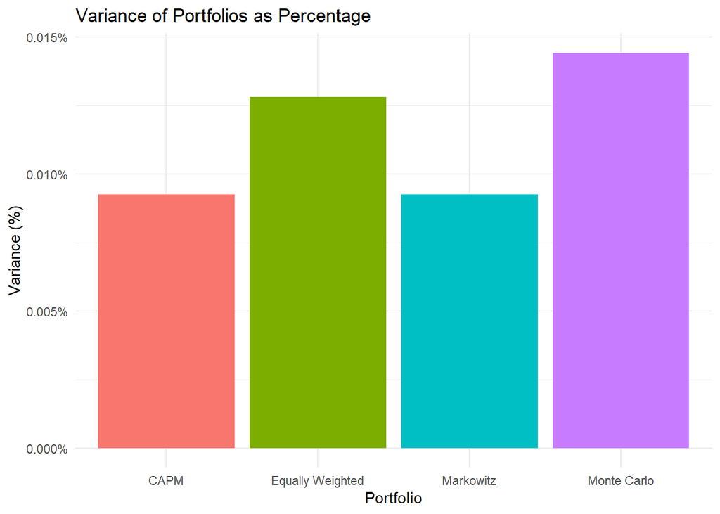

```r
variance_data$Variance <- variance_data$Variance * 100

ggplot(variance_data, aes(x = Portfolio, y = Variance, fill = Portfolio)) +
  geom_bar(stat = "identity") +
  scale_y_continuous(labels = scales::percent_format(scale = 1)) +
  labs(title = "Variance of Portfolios as Percentage",
       x = "Portfolio",
       y = "Variance (%)") +
  theme_minimal() +
  theme(legend.position = "none")
```

Calculate Beta of each portfolio for comparison (regression approach)

First, pull in the new market data:

```r
sp500Data <- getSymbols("^GSPC", src = "yahoo", from = startDate, to = endDate, auto.assign = FALSE)

if (is.null(sp500Data)) {
  stop("Failed to retrieve S&P 500 data")
} else {

  sp500Close <- Ad(sp500Data)

  marketReturn <- Return.calculate(sp500Close)

  marketReturn[1,] <- 0

  head(marketReturn)
}
```

```
##            GSPC.Adjusted
## 2023-01-03  0.0000000000
## 2023-01-04  0.0075389706
## 2023-01-05 -0.0116455289
## 2023-01-06  0.0228407810
## 2023-01-09 -0.0007676325
## 2023-01-10  0.0069782332
```

```r
calculate_beta1 <- function(portfolioReturns, marketReturn) {
    model <- lm(portfolioReturns ~ marketReturn)
    return(coef(model)[2])
}

calculate_beta2 <- function(mc_portfolioReturns, marketReturn) {
    model <- lm(mc_portfolioReturns ~ marketReturn)
    return(coef(model)[2])
}

calculate_beta3 <- function(capm_portfolioReturns, marketReturn) {
    model <- lm(capm_portfolioReturns ~ marketReturn)
    return(coef(model)[2])
}

calculate_beta4 <- function(marko_portfolioReturns, marketReturn) {
    model <- lm(marko_portfolioReturns ~ marketReturn)
    return(coef(model)[2])
}


beta1 <- calculate_beta1(portfolioReturns, marketReturn)
beta2 <- calculate_beta2(mc_portfolioReturns, marketReturn)
beta3 <- calculate_beta3(capm_portfolioReturns, marketReturn)
beta4 <- calculate_beta4(marko_portfolioReturns, marketReturn)

print(paste("Beta for Portfolio 1:", beta1))
```

```
## [1] "Beta for Portfolio 1: 1.17609654011679"
```

```r
print(paste("Beta for Portfolio 2:", beta2))
```

```
## [1] "Beta for Portfolio 2: 1.20002537294762"
```

```r
print(paste("Beta for Portfolio 3:", beta3))
```

```
## [1] "Beta for Portfolio 3: 0.659289276710059"
```

```r
print(paste("Beta for Portfolio 4:", beta4))
```

```
## [1] "Beta for Portfolio 4: 0.659289276710059"
```

[output not shown]